# Characterizing the forest using trees

Megan Cattau, Kristin Braziunas, Stella Cousins, and Allie Weill

June 24, 2016

# How do forest charcteristics vary with respect to disturbance history at Soaproot Saddle?

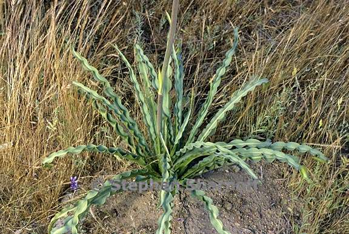

### *Using random forests to classify remotely sensed forest characteristics*

## 1. Load data

- Load LiDAR data Canopy Height, Slope, and Aspect
- Inspect the distributions

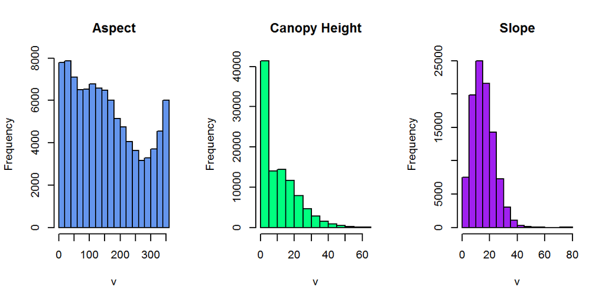

## 2. Load Hyperspectral Indices

Next, we acquired the hyperspectral indices NDVI, SAVI, ARVI, EVI, NLDI, NDNI, and PRI for the site.

- We don’t need to see that.

## 3. Brick up the vegetation indices

We used *brick* to get all the indices playing together

```r
## HI data stack
HI.data <- brick(soap_HI_NDVI, soap_HI_SAVI, soap_HI_ARVI, soap_HI_EVI, soap_HI_NDLI,
    soap_HI_NDNI, soap_HI_PRI)
```

## 4. Load Field Measurements

It is worth remembering that other people’s data is not always perfect. And that incense cedars don’t grow 130 meters tall.

```r
# Load insitu veg data
soap_insitu <- readOGR("../../NEONdata/D17-California/SOAP/2013/insitu/veg-structure",
    "soap_stems", verbose = FALSE)

# The data says there are 17 taxonids and 16 spp, so we needed to fix the
# erroneous taxonid
soap_insitu$taxonid <- gsub("CAIN3", "CEIN3", soap_insitu$taxonid)
# It's fixed! Now there are 16 taxonids and 16 scientific names
```

## 5. Import index boundaries

We extracted the flight boundaries using a special sauce

```r
# first import the boundaries
index.bounds.flight1 <- read.csv("../index_bounds.csv", sep = ",")[, 2]
```

*But where did those index boundaries come from?*

## 6. Identify plot boundaries

We wanted to match up our in situ data with the hyperspectral data so that we could subset a hyperspectral flight line. As a first step, we identified plot boundaries based on the stem locations in the in situ data.

### First, we load the in situ data as a shapefile

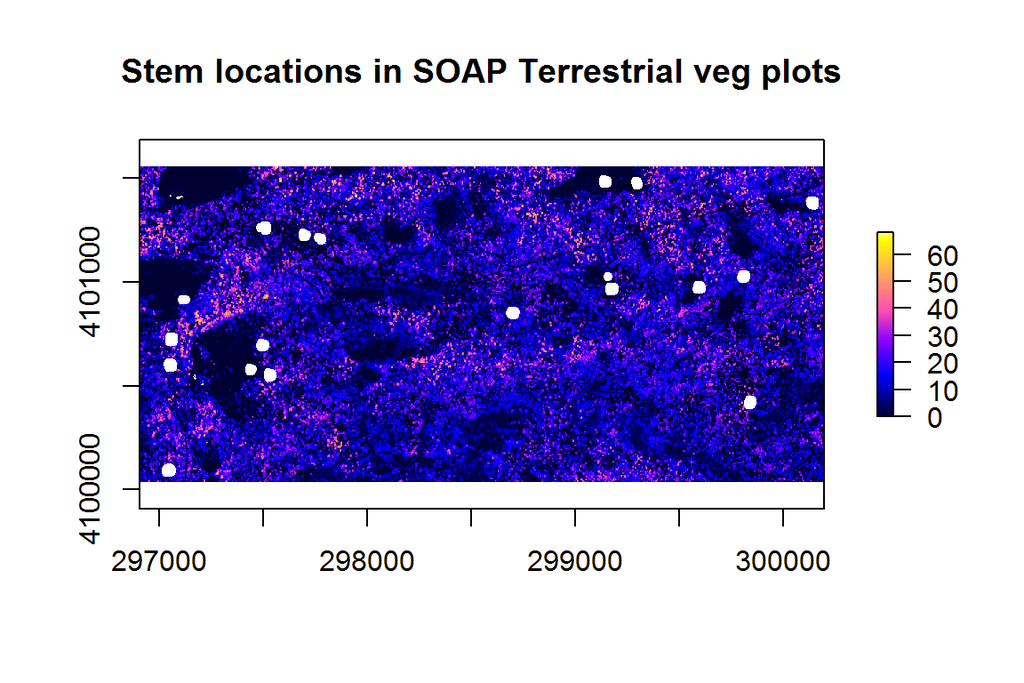

```r
stem.map <- readOGR("../../NEONdata/D17-California/SOAP/2013/insitu/veg-structure",
    "soap_stems", verbose = FALSE)

# look at a plot
chm <- raster("../../NEONdata/D17-California/SOAP/2013/lidar/SOAP_lidarCHM.tif")
plot(chm, main = "Stem locations in SOAP Terrestrial veg plots", col = bpy.colors())
plot(stem.map, pch = 20, col = "white", add = TRUE)
```

### Use stem locations to create plot boundaries

```r
# group stems by plotid, record the max and min northing and easting values
# this will be used later to create a shapefile for plot boundaries
stem.map.extent <- stem.map@data %>% group_by(plotid) %>% summarise(northing.max = max(northing) +
    5, northing.min = min(northing) - 5, easting.max = max(easting) + 5, easting.min = min(easting) -
    5)

# assign new variables for use with previously created code
yPlus <- stem.map.extent$northing.max
yMinus <- stem.map.extent$northing.min
xPlus <- stem.map.extent$easting.max
xMinus <- stem.map.extent$easting.min

# code from NEON tutorial on creating square plot extents
square <- cbind(xMinus, yPlus, xPlus, yPlus, xPlus, yMinus, xMinus, yMinus,
    xMinus, yPlus)

ID <- stem.map.extent$plotid
```

### Create spatial polygons using the coordinates

```r
# Create a function to do this
polys <- SpatialPolygons(mapply(function(poly, id) {
    xy <- matrix(poly, ncol = 2, byrow = TRUE)  # take a list and create a matrix
    Polygons(list(Polygon(xy)), ID = id)
}, split(square, row(square)), ID), proj4string = CRS(as.character("+proj=utm +zone=11 +datum=WGS84 +units=m +no_defs +ellps=WGS84 +towgs84=0,0,0")))
```

### Create shapefile

```r
polys.df <- SpatialPolygonsDataFrame(polys, data.frame(id = ID, row.names = ID))
```

### Plot this with our CHM

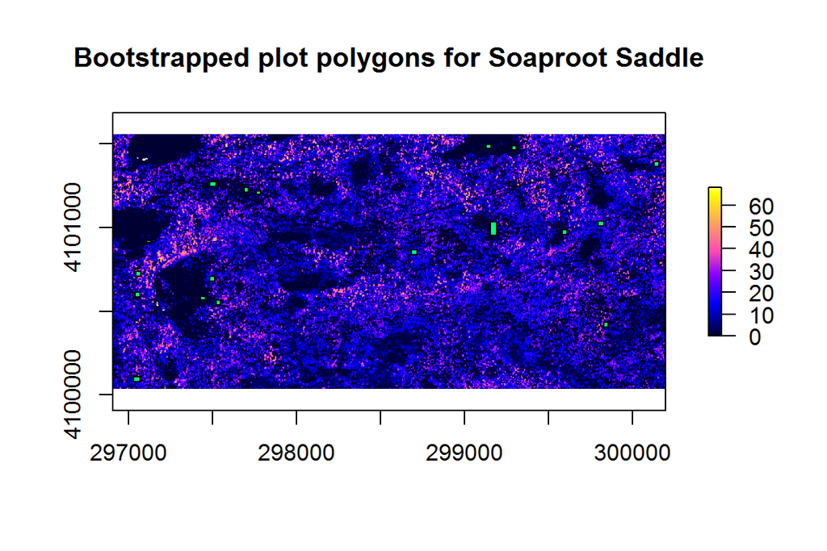

```r
plot(chm, main = "Bootstrapped plot polygons for Soaproot Saddle", col = bpy.colors())
plot(polys.df, add = TRUE, col = "springgreen", size = 2)
```

### Look at all the hyperspectral flightlines

We also used Leah’s code to get extents for all flightlines and saved this on our local computer.

### Set data directory to access hyperspectral flightline from hard drive

### Import flightline

The boundaries of the flightline appears on the plot below

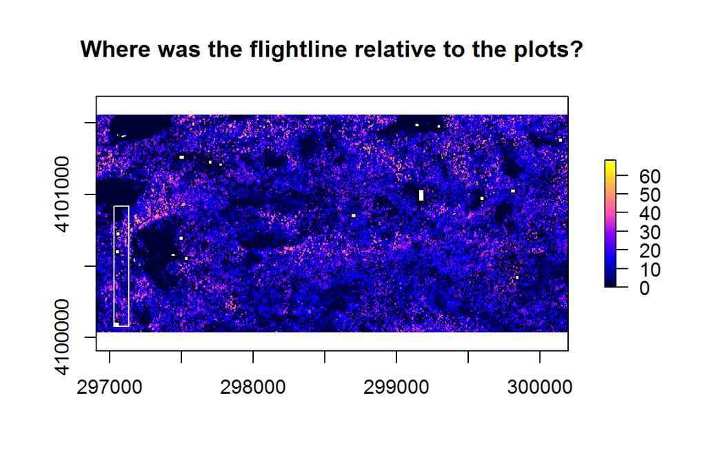

```r
# index.bounds.flight1
plot(chm, main = "Where was the flightline relative to the plots?", col = bpy.colors())
plot(polys.df, add = TRUE, col = "white")
plot(extent(all.bands.stack.flight1), add = T, col = "white")
```

```r
flight1 <- readOGR("exports/SOAP_flightLines", "NIS1_20130612_104651_atmcor",
    verbose = FALSE)

# look at this with our plots plot(chm) plot(polys.df, add=TRUE)
# plot(flight1, add=TRUE)
```

### Identify plots within flightline

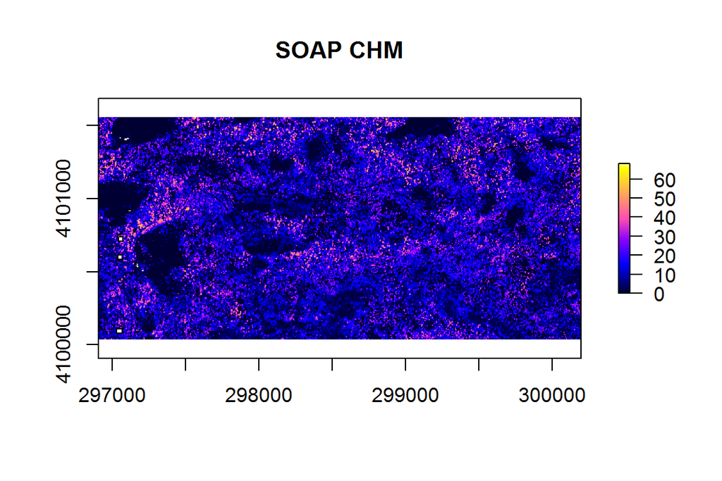

```r
# choose the plots that intersect with flight 1 for extracting HSI
flight1.plots <- raster::intersect(polys.df, flight1)
# flight1.plots

# check this subset
plot(chm, col = bpy.colors(), main = "SOAP CHM")
plot(flight1.plots, add = TRUE, col = "white")
```

### Boundary for hyperspectral subset

```r
# thanks for the code, leah!

# define the CRS definition by EPSG code
epsg <- 32611

# define the file you want to work with this is the hyperspectral flightline
# from the hard drive
f <- paste0(dataDir, "/NIS1_20130612_104651_atmcor.h5")

# define clip.extents
clip.extent <- flight1.plots

# calculate extent of H5 file
h5.ext <- create_extent(f)
# h5.ext

# turn the H5 extent into a polygon to check overlap
h5.ext.poly <- as(extent(h5.ext), "SpatialPolygons")

crs(h5.ext.poly) <- crs(clip.extent)

# test to see that the extents overlap
gIntersects(h5.ext.poly, clip.extent)

# Use the clip extent to create the index extent that can be used to slice
# out data from the H5 file xmin.index, xmax.index, ymin.index, ymax.index
# all units will be rounded which means the pixel must occupy a majority (.5
# or greater)within the clipping extent

index.bounds <- vector("list", length(clip.extent))
index.bounds <- calculate_index_extent(extent(clip.extent), h5.ext)
# index.bounds

# this is what i wrote to a csv!
```

#### *and now back, to the hyperspectral questions*

## 7. Import flightpaths previously identified

This flightpath brought to you by Leah Wasser. Thanks Leah!

```r
flight1 <- "D:/D17/SOAP/2013/SOAP_L1/SOAP_Spectrometer/Reflectance/NIS1_20130612_104651_atmcor.h5"
```

## 8. Extract bands from flightpaths

We want a band or lots of bands, but a nice, quiet band. Not a noisy one. And no stupid hats, please.

```r
# thanks to Leah, we know which bands are noisy so only importing bands that
# are not noisy

# grab all bands
bands <- c(1:192, 214:282, 316:403)

# or, if you only want RGB
bands_rgb <- c(58, 34, 19)

# Hey, European Petroleum Survey Group, this is the coordinate reference
# system this spatial data is in.
epsg <- 32611

# get stack
all.bands.stack.flight1 <- create_stack(flight1, bands, epsg, subset = TRUE,
    dims = index.bounds.flight1)

rgb.bands.stack.flight1 <- create_stack(flight1, bands_rgb, epsg, subset = TRUE,
    dims = index.bounds.flight1)
```

## 9. Now, we can see where the information is coming from

A little slice of Sierra Nevada called Soaproot Saddle This is a small corner of the extent at Soaproot The overlay is from our flight of interest.

## 10. Examine the spectra to be used for analysis

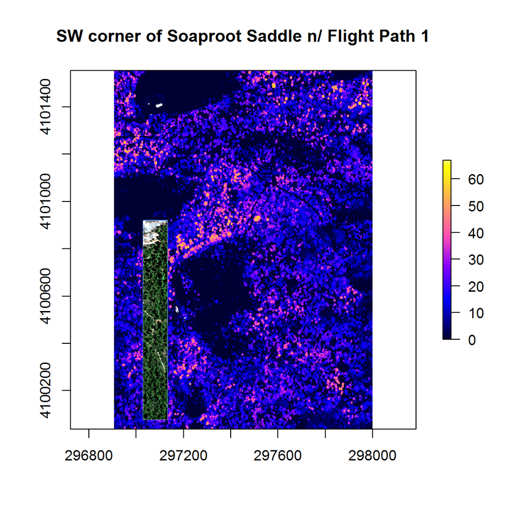

```r
# check via plotting to make sure we got the right areas
plot(soap_chm, xlim = c(296800, 298000), col = bpy.colors(), main = "SW corner of Soaproot Saddle n/ Flight Path 1")
# extent of the hsi flight stack in appropriate colors
plot(extent(all.bands.stack.flight1), add = T, col = "cornflower blue", size = 2)
# the rgb bands for that region
plotRGB(rgb.bands.stack.flight1, stretch = "lin", add = T)
```

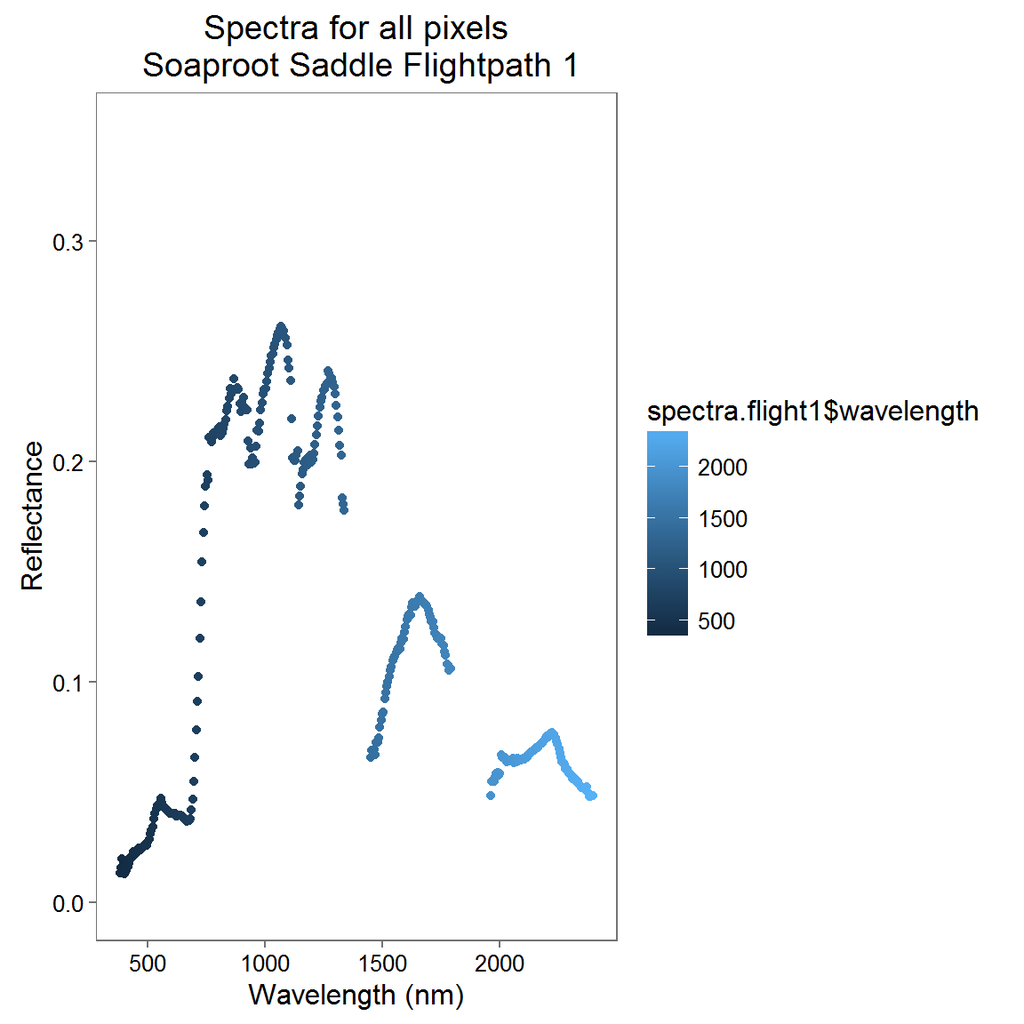

```r
# also take a look at the wavelength plots

# get spectra for each band
spectra.flight1 <- extract_av_refl(all.bands.stack.flight1, aFun = mean)
spectra.flight1 <- as.data.frame(spectra.flight1)

# read in the wavelength information from the HDF5 file
wavelengths <- h5read(flight1, "wavelength")

# convert wavelength to nanometers (nm)
wavelengths <- wavelengths * 1000
spectra.flight1$wavelength <- wavelengths[bands]

# plot spectra
spectra_plot <- qplot(x = spectra.flight1$wavelength, y = spectra.flight1$spectra.flight1,
    xlab = "Wavelength (nm)", ylab = "Reflectance", main = "Spectra for all pixels\n Soaproot Saddle Flightpath 1",
    ylim = c(0, 0.35), colour = spectra.flight1$wavelength)
spectra_plot + theme_few()
```

## Next: why this pattern? Is it related to a disturbance?